# Deliverable 4

#### q.pickup_latitude

```r
summary(res.imputation$completeObs[,"q.pickup_latitude"])
```

```
##    Min. 1st Qu.  Median    Mean 3rd Qu.    Max.
##   40.58   40.70   40.75   40.75   40.80   40.86
```

#### q.dropoff_longitude

```r
summary(res.imputation$completeObs[,"q.dropoff_longitude"])
```

```
##    Min. 1st Qu.  Median    Mean 3rd Qu.    Max.
##  -74.06  -73.97  -73.94  -73.94  -73.91  -73.80
```

#### q.dropoff_latitude

```r
summary(res.imputation$completeObs[,"q.dropoff_latitude"])
```

```
##    Min. 1st Qu.  Median    Mean 3rd Qu.    Max.
##   40.58   40.70   40.75   40.74   40.79   40.86
```

#### q.passenger_count

We decided to create categorical for this variable so we categorize it for single passengers, couple and groups (3 or more)

```r
df$f.passenger_groups[res.imputation$completeObs[,"q.passenger_count"]  == 1] = "passenger_single"
df$f.passenger_groups[res.imputation$completeObs[,"q.passenger_count"] > 1 & res.imputation$completeObs[,"q.passenger_count"] <= 2] = "passenger_couple"
df$f.passenger_groups[res.imputation$completeObs[,"q.passenger_count"] >= 3] = "passenger_group"
df$f.passenger_groups <- factor(df$f.passenger_groups)
```

We see the barplot in order to see the distribution of passenger per trip

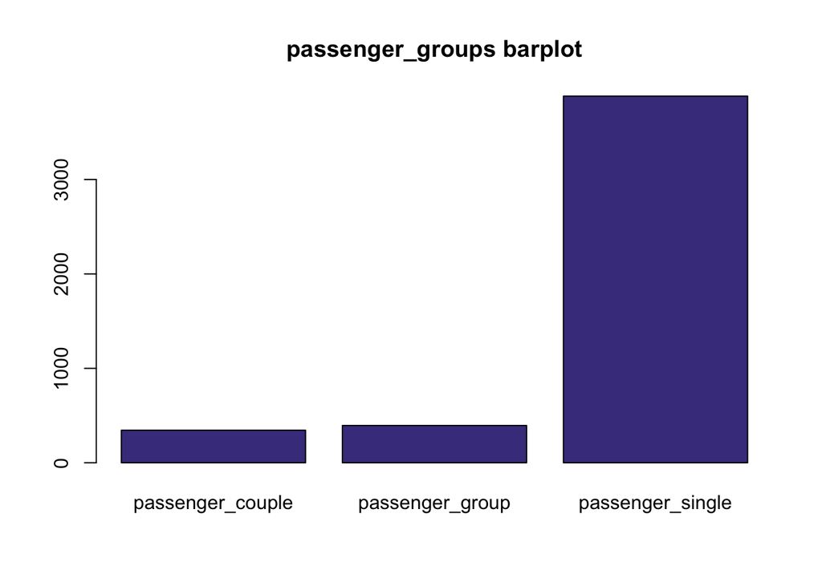

```r
barplot(table(df$f.passenger_groups),main="passenger_groups barplot",col="darkslateblue")
```

#### q.trip_distance

```r
ll<-which(res.imputation$completeObs[,"q.trip_distance"] < 0)
res.imputation$completeObs[ll,"q.trip_distance"] <- 1
ll<-which(res.imputation$completeObs[,"q.trip_distance"] > 30)
res.imputation$completeObs[ll,"q.trip_distance"] <- 30
```

#### q.fare_amount

```r
ll<-which(res.imputation$completeObs[,"q.fare_amount"] > 60)
res.imputation$completeObs[ll,"q.fare_amount"] <- 60
```

#### q.extra

If we execute a table, we’ll see that we have 0, 0’5 and 1 values, so we proceed to categorize this variable to see if has extra or not.

```r
table(df$q.extra)
```

```
##
##    0  0.5    1
## 2128 1733  762
```

```r
df$f.extra[df$q.extra == 0] = 0
df$f.extra[df$q.extra > 0] = 1
df$f.extra<-factor(df$f.extra, labels=c("extra_no","extra_yes"))
```

We see the barplot in order to see the distribution.

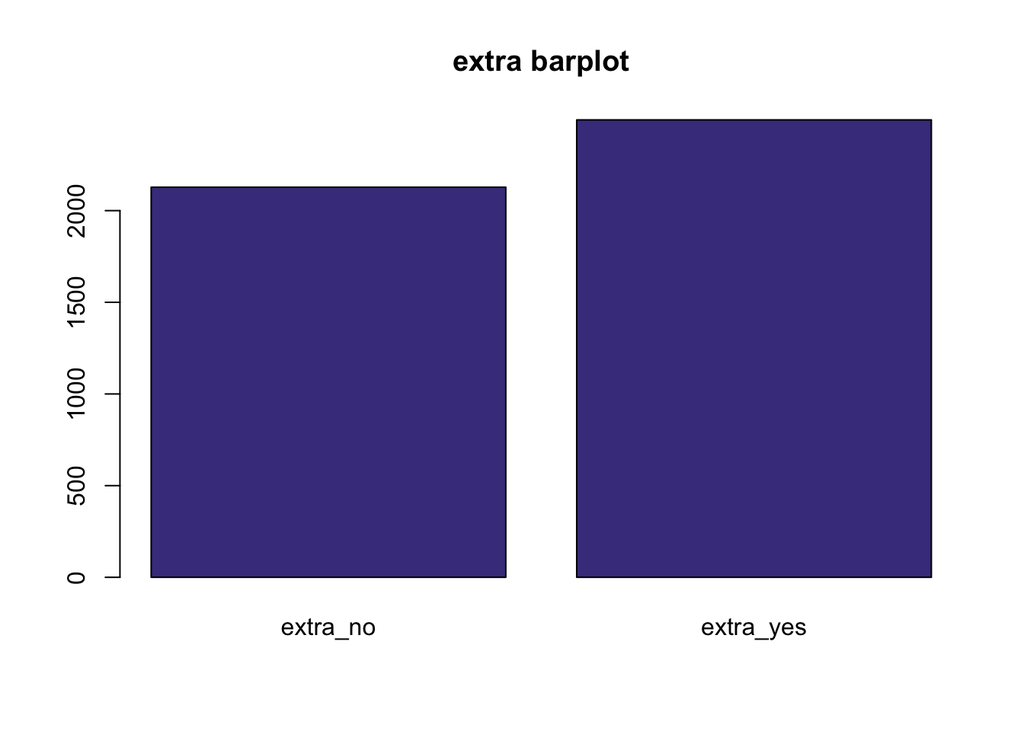

```r
barplot(table(df$f.extra),main="extra barplot",col="darkslateblue")
```

#### q.mta_tax If we execute a summary, we’ll see that every value should be 0.5 or 0, so we proceed to categorize this variable in order to see if the tax has been paid or not.

```r
table(df$q.mta_tax)
```

```
##
##    0  0.5
##  119 4504
```

```r
df$f.mta_tax<-factor(df$q.mta_tax, labels =c("mta_no","mta_yes"))
```

We see the barplot in order to see the distribution.

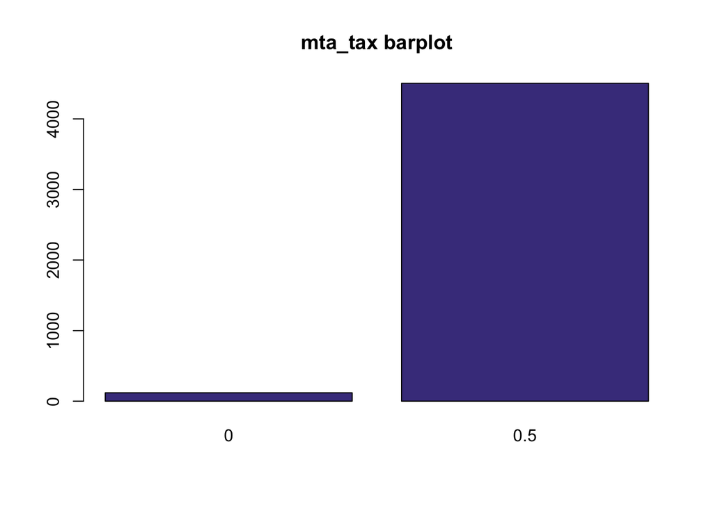

```r
barplot(table(df$q.mta_tax),main="mta_tax barplot",col="darkslateblue")
```

#### q.tip_amount

```r
ll<-which(res.imputation$completeObs[,"q.tip_amount"] > 17)
res.imputation$completeObs[ll,"q.tip_amount"] <- 17
```

We see that we have correct data, so we proceed to create the binary factor TipIsGiven.

```r
df$f.target.tip_is_given[(res.imputation$completeObs[,"q.tip_amount"] > 0)] = "tip_yes"
df$f.target.tip_is_given[(res.imputation$completeObs[,"q.tip_amount"] == 0)] = "tip_no"
df$f.target.tip_is_given <- factor(df$f.target.tip_is_given)
summary(df$f.target.tip_is_given)
```

```
##  tip_no tip_yes
##    2882    1741
```

#### q.tolls_amount

As we checked before the imputation and detected as errors those individuals with negative amount, the negative values found now are going to be set as 0 because they result negative during the imputation. After treating this values, we proceed to categorize this variable to see if an individual has paid or not for a toll.

```r
ll<-which(res.imputation$completeObs[,"q.tolls_amount"] < 0)
res.imputation$completeObs[ll,"q.tolls_amount"] <- 0

df$f.paid_tolls[res.imputation$completeObs[,"q.tolls_amount"] == 0] = "tolls_no"
df$f.paid_tolls[res.imputation$completeObs[,"q.tolls_amount"] > 0] = "tolls_yes"
df$f.paid_tolls <- factor(df$f.paid_tolls)
```

#### q.improvement_surcharge

If we execute a table, we’ll see that every value should be 0.3 or 0, so we proceed to categorize this variable in order to see if the surcharge has been paid or not.

```r
table(df$q.improvement_surcharge)
```

```
##
##    0  0.3
##  118 4505
```

```r
df$f.improvement_surcharge<-factor(df$q.improvement_surcharge, labels=c("improvement_no","improvement_yes"))
```

We see the barplot in order to see the distribution.

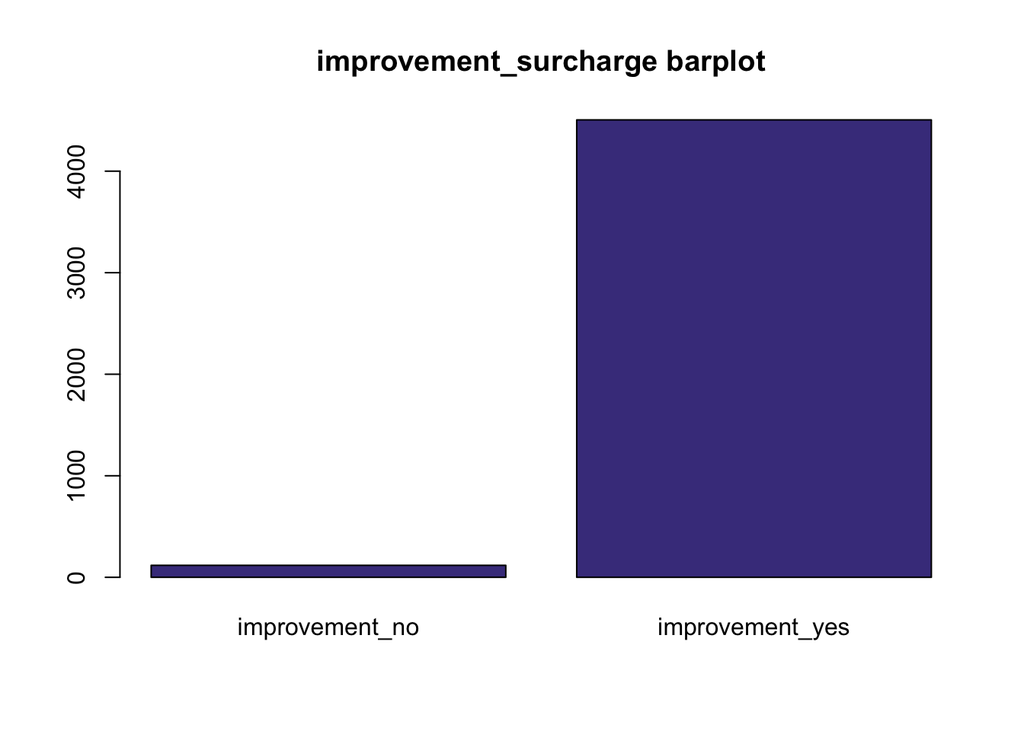

```r
barplot(table(df$f.improvement_surcharge),main="improvement_surcharge barplot",col="darkslateblue")
```

#### q.tlenkm

```r
ll<-which(res.imputation$completeObs[,"q.tlenkm"] <= 1)
res.imputation$completeObs[ll,"q.tlenkm"] <- 1
ll<-which(res.imputation$completeObs[,"q.tlenkm"] > 48.28)
res.imputation$completeObs[ll,"q.tlenkm"] <- 48.28
```

```r
ll<-which(res.imputation$completeObs[,"q.tlenkm"] > 60)
res.imputation$completeObs[ll,"q.tlenkm"] <- 60
```

#### q.espeed

```r
ll<-which(res.imputation$completeObs[,"q.espeed"] < 3)
res.imputation$completeObs[ll,"q.espeed"] <- 3
ll<-which(res.imputation$completeObs[,"q.espeed"] > 55)
res.imputation$completeObs[ll,"q.espeed"] <- 55
```

#### Store imputation

We proceed to impute all NAs in our numerical variables that are stored in: `res.imputation$completeObs`

```r
df[,vars_quantitatives] <- res.imputation$completeObs
```

### Categorical variables / Factors

```r
vars_categorical<-names(df)[c(1,2,3,17,18,20,26,27,28,29,30,31,32)]
summary(df[,vars_categorical])
```

```
##              f.vendor_id   f.store_and_fwd_flag            f.rate_code_id
##  vendor_id_mobile  : 973   flag-no :4605        rate_code_id_1    :4496
##  vendor_id_verifone:3650   flag-yes:  18        rate_code_id_other: 127
##
##
##      f.payment_type           f.trip_type               f.period
##  credit card:2096   trip_street_hail:4511   period night    :1642
##  cash       :2497   trip_dispatch   : 112   period morning  : 542
##  no paid    :  30                           period valley   :1260
##                                             period afternoon:1179
##       f.trip_distance_range        f.passenger_groups      f.extra
##  trip_dist_long  : 645      passenger_couple: 345     extra_no :2128
##  trip_dist_medium: 986      passenger_group : 395     extra_yes:2495
##  trip_dist_short :2930      passenger_single:3883
##  NA's            :  62
##    f.mta_tax    f.target.tip_is_given    f.paid_tolls
##  mta_no : 119   tip_no :2882          tolls_no :4576
##  mta_yes:4504   tip_yes:1741          tolls_yes:  47
##
##
##     f.improvement_surcharge
##  improvement_no : 118
##  improvement_yes:4505
##
##
```

```r
res.input<-imputeMCA(df[,vars_categorical],ncp=10)
summary(res.input$completeObs)
```

```
##              f.vendor_id   f.store_and_fwd_flag            f.rate_code_id
##  vendor_id_mobile  : 973   flag-no :4605        rate_code_id_1    :4496
##  vendor_id_verifone:3650   flag-yes:  18        rate_code_id_other: 127
##
##
##      f.payment_type           f.trip_type               f.period
##  credit card:2096   trip_street_hail:4511   period night    :1642
##  cash       :2497   trip_dispatch   : 112   period morning  : 542
##  no paid    :  30                           period valley   :1260
##                                             period afternoon:1179
##       f.trip_distance_range        f.passenger_groups      f.extra
##  trip_dist_long  : 650      passenger_couple: 345     extra_no :2128
##  trip_dist_medium: 988      passenger_group : 395     extra_yes:2495
##  trip_dist_short :2985      passenger_single:3883
##
##    f.mta_tax    f.target.tip_is_given    f.paid_tolls
##  mta_no : 119   tip_no :2882          tolls_no :4576
##  mta_yes:4504   tip_yes:1741          tolls_yes:  47
##
##
##     f.improvement_surcharge
##  improvement_no : 118
##  improvement_yes:4505
##
##
```

#### Store imputation

```r
df[,vars_categorical] <- res.input$completeObs
```

### Create some other factors after imputation

#### f.dist

```r
df$f.dist[df$q.trip_distance<=1.6] = "(0, 1.6]"
df$f.dist[(df$q.trip_distance>1.6) & (df$q.trip_distance<=3)] = "(1.6, 3]"
df$f.dist[(df$q.trip_distance>3) & (df$q.trip_distance<=5.5)] = "(3, 5.5]"
df$f.dist[(df$q.trip_distance>5.5) & (df$q.trip_distance<=30)] = "(5.5, 30]"
df$f.dist<-factor(df$f.dist)
```

#### f.hour

```r
df$f.hour[(df$q.hour>=17) & (df$q.hour<18)] = "17"
df$f.hour[(df$q.hour>=18) & (df$q.hour<19)] = "18"
df$f.hour[(df$q.hour>=19) & (df$q.hour<20)] = "19"
df$f.hour[(df$q.hour>=20) & (df$q.hour<21)] = "20"
df$f.hour[(df$q.hour>=21) & (df$q.hour<22)] = "21"
df$f.hour[(df$q.hour>=22) & (df$q.hour<23)] = "22"
df$f.hour[(df$q.hour<17)] = "other"
df$f.hour[(df$q.hour>=23)] = "other"
df$f.hour<-factor(df$f.hour)
```

#### f.espeed

```r
df$f.espeed[(df$q.espeed>=3) & (df$q.espeed<20)]  = "[03,20)"
df$f.espeed[(df$q.espeed>=20) & (df$q.espeed<40)] = "[20,40)"
df$f.espeed[(df$q.espeed>=40) & (df$q.espeed<=55)] = "[40,55]"
df$f.espeed<-factor(df$f.espeed)
```

### Describe these variables, to which other variables exist higher associations

#### Compute the correlation with all other variables.

We are skipping longitudes and latitudes.

```r
library(mvoutlier)
library(FactoMineR)
vars_quantitatives_no_coords <- names(df)[c(8,9,10,11,12,13,14,15,16,21,22,23)]
res <- cor(df[,vars_quantitatives_no_coords])
round(res, 2)
```

```
##                         q.passenger_count q.trip_distance q.fare_amount q.extra
## q.passenger_count                    1.00            0.02          0.01    0.05
## q.trip_distance                      0.02            1.00          0.92   -0.05
## q.fare_amount                        0.01            0.92          1.00   -0.06
## q.extra                              0.05           -0.05         -0.06    1.00
## q.mta_tax                            0.00           -0.08         -0.10    0.15
## q.tip_amount                        -0.01            0.42          0.42    0.01
## q.tolls_amount                       0.02            0.20          0.20   -0.03
## q.improvement_surcharge              0.01           -0.07         -0.08    0.15
## q.target.total_amount                0.02            0.91          0.95   -0.01
## q.tlenkm                             0.02            0.99          0.91   -0.05
## q.travel_time                        0.00            0.11          0.12    0.03
## q.espeed                             0.02            0.57          0.41   -0.05
##                         q.mta_tax q.tip_amount q.tolls_amount
## q.passenger_count            0.00        -0.01           0.02
## q.trip_distance             -0.08         0.42           0.20
## q.fare_amount               -0.10         0.42           0.20
## q.extra                      0.15         0.01          -0.03
## q.mta_tax                    1.00         0.04           0.01
## q.tip_amount                 0.04         1.00           0.18
## q.tolls_amount               0.01         0.18           1.00
## q.improvement_surcharge      0.96         0.05           0.02
## q.target.total_amount       -0.05         0.57           0.25
## q.tlenkm                    -0.04         0.41           0.21
## q.travel_time                0.01         0.02           0.00
## q.espeed                    -0.08         0.21           0.16
##                         q.improvement_surcharge q.target.total_amount q.tlenkm
## q.passenger_count                          0.01                  0.02     0.02
## q.trip_distance                           -0.07                  0.91     0.99
## q.fare_amount                             -0.08                  0.95     0.91
## q.extra                                    0.15                 -0.01    -0.05
## q.mta_tax                                  0.96                 -0.05    -0.04
## q.tip_amount                               0.05                  0.57     0.41
## q.tolls_amount                             0.02                  0.25     0.21
## q.improvement_surcharge                    1.00                 -0.03    -0.03
## q.target.total_amount                     -0.03                  1.00     0.88
## q.tlenkm                                  -0.03                  0.88     1.00
## q.travel_time                              0.01                  0.11     0.11
## q.espeed                                  -0.07                  0.40     0.56
##                         q.travel_time q.espeed
## q.passenger_count                0.00     0.02
## q.trip_distance                  0.11     0.57
## q.fare_amount                    0.12     0.41
## q.extra                          0.03    -0.05
## q.mta_tax                        0.01    -0.08
## q.tip_amount                     0.02     0.21
## q.tolls_amount                   0.00     0.16
## q.improvement_surcharge          0.01    -0.07
## q.target.total_amount            0.11     0.40
## q.tlenkm                         0.11     0.56
## q.travel_time                    1.00    -0.14
## q.espeed                        -0.14     1.00
```